# 英语音节心理声学研究热点图程序

夏骁凯

对胡伟老师的实验进行可视化尝试，使用 ggplot2 包进行绘图，colorspace 包进行颜色选择。

### 1. 数据结构的实现：

考虑 ggplot2 需要数据框作为数据数据结构，同时选择 geom_tile 作为绘图函数，涉及到的 aes 包括 x，y，fill，因而设计的数据框结构如下：

| x | y | fill |
| --- | --- | --- |
| 1 | 1 | #000000 |
| 1 | 2 | #000001 |

其中，x，y 分别表示横纵坐标，fill 为 HCL 色值。 同时，为了便于程序随后的修改与扩展性，因而在本数据框加入数据分析的数据源，包括对不同单词出现频率，以及使用条件判断语句决定是否需要混色的factor。使用 wide-table 的形式表现，因此数据框结构如下：

| x | y | heed | hid | hood | head | mix | fill |
| --- | --- | --- | --- | --- | --- | --- | --- |
| 1 | 2 | 5 | 3 | 2 | 0 | 1 | #000000 |

### 2. 混色的实现：

由于为了使不同的数据通过颜色混合的形式表达出来，因此需要工具对色彩进行分析与混合，预期的方法是将特定的词频的颜色进行指定，随后根据映射关系将相应的色彩进行混合。查询 CRAN 后选择 colorspace 完成相应任务。

colorspace 是一个进行调色的 R package。CRAN 上的地址为：https://cran.r-project.org/web/packages/colorspace/ 。该工具包提供 vignettes ，地址为：https://cran.r-project.org/web/packages/colorspace/vignettes/hcl-colors.pdf 。本文的色彩实现主要通过该 vignettes 。

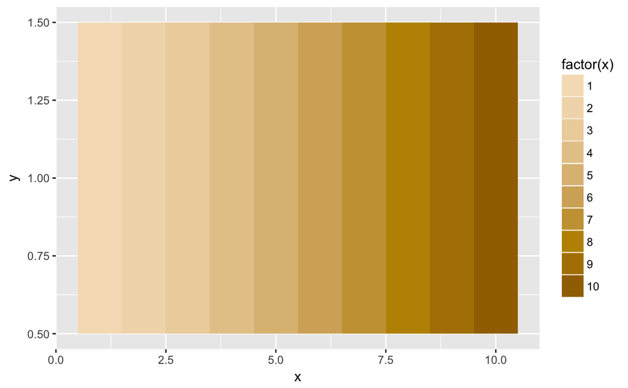

```r
library(colorspace)
library(tidyverse)
color <- sequential_hcl(10, h = 60, c = c(100, 30), l = c(50, 90))
colortable <- data.frame(x = 1:10, y = 1, color = color) #构造绘图函数
names(color) <- factor(10:1) #构造色彩映射
ggplot(colortable, aes(x = x, y = y, fill = factor(x))) + geom_tile() + scale_fill_manual(values = color)
```

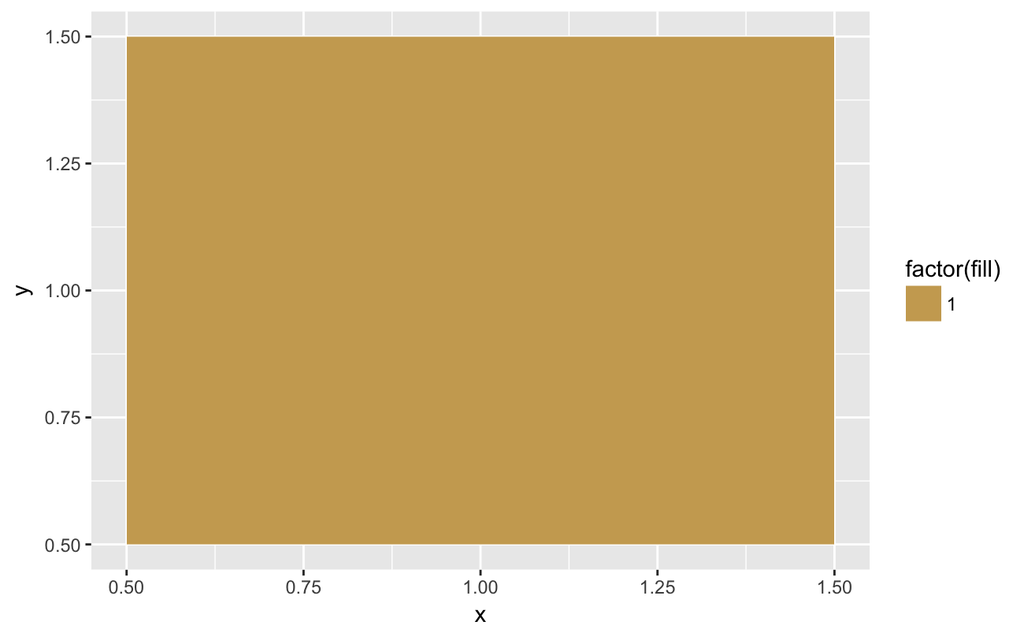

```r
mixcolorhcl <- function(first, second) {
  hex(mixcolor(alpha = 0.5,
               color1 = hex2RGB(first), color2 = hex2RGB(second)))
}
mixcolor <- mixcolorhcl(color[1], color[10])
names(mixcolor) <- "1"
mixtable <- data.frame(x = 1, y = 1, fill = 1)
ggplot(mixtable, aes(x = x, y = y, fill = factor(fill))) + geom_tile() + scale_fill_manual(values = mixcolor)
```

### 3. 表格的制作

```r
#配置分析环境
library(stringr)
#导入实验数据
en_nv <- read.csv(file.choose(), header = T)
en_ihiy <- read.csv(file.choose(), header = T)
#对数据进行初步筛选与整理
en_nv <- select(en_nv, answer1.Block., sound111, sound112)
en_ihiy <- select(en_ihiy, answer1.SubTrial.,answer2.SubTrial.,starts_with("sound"))
names(en_nv)[1] <- "answer"
names(en_ihiy)[1] <- "answer"
names(en_ihiy)[2] <- "rate"
en_ihiy$rate <- stringr::str_sub(en_ihiy$rate, start = 2, end = -1)
#制作实验1的表格
en_nv <- unite(en_nv, sound, sound111, sound112)
en_ihiy <- unite(en_ihiy, col = sound, sound111, sound112, sound113, sound114, sound115, sound121, sound122, sound123, sound124, sound125)
#清除缺失值
en_nv <- na.omit(en_nv)
en_ihiy <- na.omit(en_ihiy)
#对数据中的文件路径含义进行修改
#将实验1的文件路径改为对应单词，并确认是否匹配
en_nv$sound <- str_extract(en_nv$sound, pattern = "(w|h).*d")
en_nv <- mutate(en_nv, match = sound == answer)
table(en_nv$match, en_nv$sound)
```

```
        had hawed hayed head heard heed hid hod hoed hood hud whod
  FALSE  15    15    15   11     0    5  15  16   16   16  16   20
  TRUE    4     4     2    8    20   14   5   4    3    4   4    0
```

```r
#复杂频数表
# ftable实现
ftable(en_nv, row.vars = c(1,3), col.vars = 2)
```

```
             sound had hawed hayed head heard heed hid hod hoed hood hud whod
answer match
had    FALSE         0     0     1   10     0    0   0   0    0    0   4    0
       TRUE          4     0     0    0     0    0   0   0    0    0   0    0
hawed  FALSE         1     0     0    0     0    0   0   3    2    0   4    0
       TRUE          0     4     0    0     0    0   0   0    0    0   0    0
hayed  FALSE         1     0     0    0     0    0   2   0    0    0   0    0
       TRUE          0     0     2    0     0    0   0   0    0    0   0    0
head   FALSE         7     1     6    0     0    1   3   0    0    0   2    0
       TRUE          0     0     0    8     0    0   0   0    0    0   0    0
heard  FALSE         0     0     0    0     0    0   0   5    0    0   5    0
       TRUE          0     0     0    0    20    0   0   0    0    0   0    0
heed   FALSE         2     0     5    0     0    0   5   0    0    0   0    0
       TRUE          0     0     0    0     0   14   0   0    0    0   0    0
hid    FALSE         0     0     2    0     0    4   0   0    0    0   0    0
       TRUE          0     0     0    0     0    0   5   0    0    0   0    0
hod    FALSE         1     2     0    1     0    0   0   0    2    1   0    0
       TRUE          0     0     0    0     0    0   0   4    0    0   0    0
hoed   FALSE         1     5     1    0     0    0   4   2    0    0   0    1
       TRUE          0     0     0    0     0    0   0   0    3    0   0    0
hood   FALSE         1     7     0    0     0    0   0   4    6    0   1    7
       TRUE          0     0     0    0     0    0   0   0    0    4   0    0
hud    FALSE         1     0     0    0     0    0   1   2    3   14   0   12
       TRUE          0     0     0    0     0    0   0   0    0    0   4    0
whod   FALSE         0     0     0    0     0    0   0   0    3    1   0    0
       TRUE          0     0     0    0     0    0   0   0    0    0   0    0
```

```r
#将实验2的文件路径改为定位坐标
en_ihiy$sound <- str_extract(en_ihiy$sound, pattern = "F1_..-F2_..")
en_ihiy <- separate(en_ihiy, col = sound, into = c("X","Y"), sep = "-")
en_ihiy$X <- as.numeric(str_replace(en_ihiy$X, pattern = "F1_", replacement = ""))
en_ihiy$Y <- as.numeric(str_replace(en_ihiy$Y, pattern = "F2_", replacement = ""))
#对实验2中出现的单词数进行计数
summary(en_ihiy$answer)
```

```
  had hawed hayed  head heard  heed   hid   hod  hoed  hood   hud  whod
  185   145   249   504   381   370   398   187   213   162    80    55
```

### 4. 绘制 heatmap

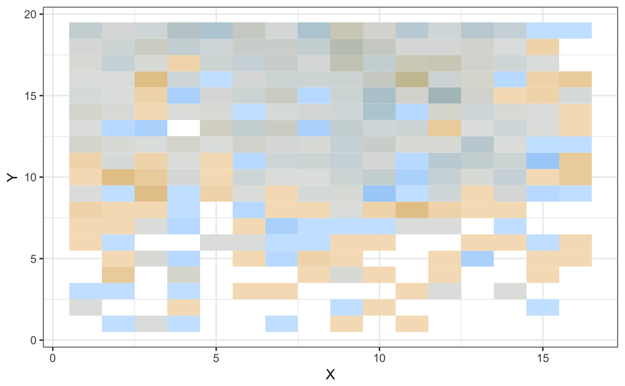

```r
data_en_ihiy <- reshape2::dcast(en_ihiy, X + Y ~ answer)
#选择出现频率最高的几个单词作为绘图依据
data_en_ihiy <- select(data_en_ihiy, X, Y, heed, hid)
data_en_ihiy[data_en_ihiy == 0] <- NA
#构造色彩映射
heed_color <- sequential_hcl(10, h = 60, c = c(100, 30), l = c(50, 90))
names(heed_color) <- factor(str_c("heed",10:1))
hid_color <- sequential_hcl(10, h = 240, c = c(100, 30), l = c(50, 90))
names(hid_color) <- factor(str_c("hid",10:1))
hood_color <- sequential_hcl(10, h = 190, c = c(100, 30), l = c(50, 90))
names(hood_color) <- factor(str_c("hood",10:1))
head_color <- sequential_hcl(10, h = 280, c = c(100, 30), l = c(50, 90))
names(head_color) <- factor(str_c("head",10:1))
color_total <- c(heed_color, hid_color)
#制作绘图参考值的表格
data_en_ihiy <- mutate(data_en_ihiy, heedcolor = heed, hidcolor = hid)
data_en_ihiy$heedcolor <- str_c("heed", data_en_ihiy$heedcolor)
data_en_ihiy$hidcolor <- str_c("hid", data_en_ihiy$hidcolor)
#data_en_ihiy$hoodcolor <- str_c("hood", data_en_ihiy$hoodcolor)
#data_en_ihiy$headcolor <- str_c("head", data_en_ihiy$headcolor)
#统计是否需要颜色混合
count <- vector()
for(i in 1:nrow(data_en_ihiy)){
  count[i] <- sum(is.na(data_en_ihiy[i,3:4]) == FALSE)
}
data_en_ihiy <- cbind(data_en_ihiy, count)
#建立整合色彩函数
select_one_color <- function(x){
  a <- select(x, heedcolor, hidcolor)
  b <- a[which(is.na(a) == FALSE)]
  return(color_total[[b[[1]]]])
}
mix_two_color <- function(x){
  a <- select(x, heedcolor, hidcolor)
  b <- a[which(is.na(a) == FALSE)]
  c <- mixcolorhcl(color_total[[b[[1]]]], color_total[[b[[2]]]])
  return(c)
}
mix_three_color <- function(x){
  a <- select(x, heedcolor, hidcolor)
  b <- a[which(is.na(a) == FALSE)]
  c <- mixcolorhcl(color_total[[b[[1]]]], color_total[[b[[2]]]])
  d <- mixcolorhcl(c, color_total[[b[[3]]]])
  return(d)
}
mix_four_color <- function(x){
  a <- select(x, heedcolor, hidcolor, hoodcolor, headcolor)
  b <- a[which(is.na(a) == FALSE)]
  c <- mixcolorhcl(color_total[[b[[1]]]], color_total[[b[[2]]]])
  d <- mixcolorhcl(color_total[[b[[4]]]], color_total[[b[[3]]]])
  e <- mixcolorhcl(c,d)
  return(e)
}

#构建色彩映射向量
color_map <- vector()
data_en_ihiy <- filter(data_en_ihiy, count > 0)
for(i in 1 : nrow(data_en_ihiy)){
  z <- data_en_ihiy[i,]
  color_map[i] <- switch(z$count,
    select_one_color(z),
    mix_two_color(z)
  )
}
names(color_map) <- as.character(1:nrow(data_en_ihiy))
#构造填字内容列（如果要改单词，需要把下面的三个*_table的赋值都进行修改）
temp_table <- select(data_en_ihiy,heed, hid) #用于比较大小的表格
cheak_table <- select(data_en_ihiy, X,Y, heed, hid) #用于选择相应比例值的表格
rate_map <- vector()
temp_table[is.na(temp_table)] <- 0
for(i in 1 : nrow(temp_table)){
 char_num <- which(temp_table[i,] == max(temp_table[i,]))

 x <- cheak_table[i, ]$X
 y <- cheak_table[i, ]$Y

 get_rate_table <- en_ihiy %>%
  filter(X == x, Y == y, answer == "heed"|answer=="hid") %>%  #记得这里也要修改
  group_by(answer) %>%
  summarise(mean(as.numeric(rate)))
 judge_name <- names(temp_table)

 if(length(char_num) != 1){
  rate_map[i] <- max(get_table$`mean(as.numeric(rate))`)
}else{
  get_rate <- get_table %>%
   filter(answer == judge_name[char_num])
  rate_map[i] <- get_rate[[2]]
  }
}
data_en_ihiy <- cbind(data_en_ihiy, rate_map)
position <- c(1:nrow(data_en_ihiy))
data_en_ihiy <- cbind(data_en_ihiy, position)
figure_without_text <- ggplot(data_en_ihiy, aes(x = X, y = Y, fill = as.factor(position))) + geom_tile(show.legend = F) + scale_fill_manual(values = color_map) + theme_bw()
figure_with_text <- ggplot(data_en_ihiy, aes(x = X, y = Y, fill = as.factor(position))) + geom_tile(show.legend = F) + scale_fill_manual(values = color_map) + theme_bw() + geom_text(aes(label = rate_map)) + coord_equal(ratio = 1)
ggsave("figure_with_text.pdf", plot = figure_with_text)
ggsave("figure_without_text.pdf", plot = figure_without_text)
ggplot(data_en_ihiy, aes(x = X, y = Y, fill = as.factor(position))) + geom_tile(show.legend = F) + scale_fill_manual(values = color_map) + theme_bw()
```

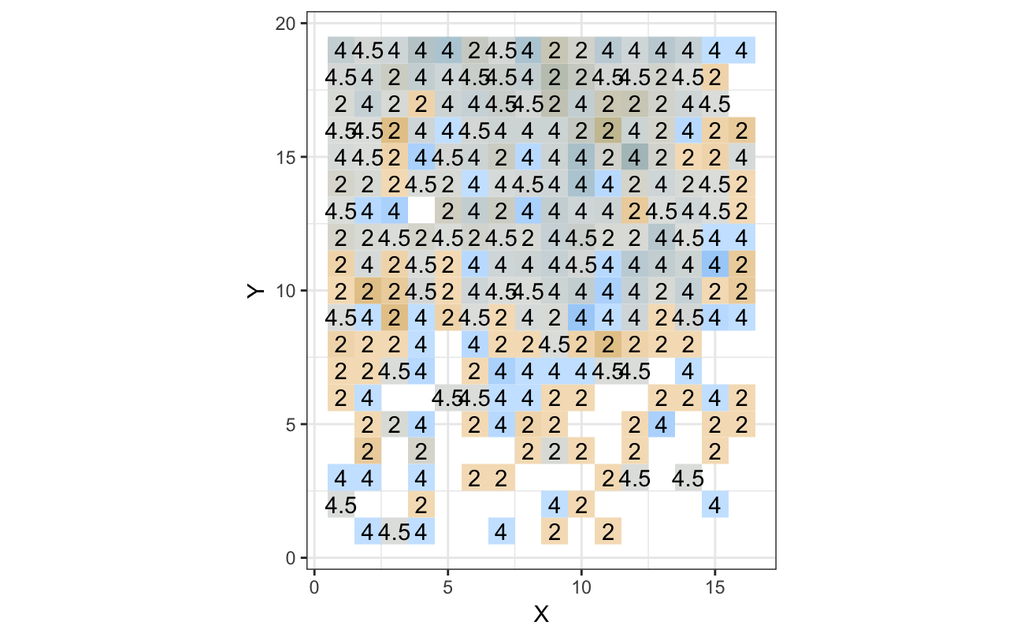

```r
ggplot(data_en_ihiy, aes(x = X, y = Y, fill = as.factor(position))) + geom_tile(show.legend = F) + scale_fill_manual(values = color_map) + theme_bw() + geom_text(aes(label = rate_map)) + coord_equal(ratio = 1)
```